# Using a custom statistic with its error bar

By default, `superbPlot` generates mean plots along with 95% confidence intervals of the mean. However, these choices can be changed.

- To change the summary statistics, use the argument `statistic =`;
- To change the interval function, use the argument `errorbar =`. The abbreviation `CI` stands for confidence interval; `SE` stands for standard error.
- With `CI`, to change the confidence level, use the argument `gamma =`;

The defaults are `statistic = "mean", errorbar = "CI", gamma = 0.95`. For error bar functions that accept a gamma parameter (e.g., `CI`, the gamma parameter is automatically transfered to the function). For other functions that do not accept a gamma parameter (e.g., `SE`), the gamma parameter is unused.

## Changing the summary function to be plotted

In what follow, we use `GRD()` to generate a random dataset with an interaction (see [Vignette 6](https://dcousin3.github.io/superb/articles/Vignette6.html)) then make plots varying the statistics displayed.

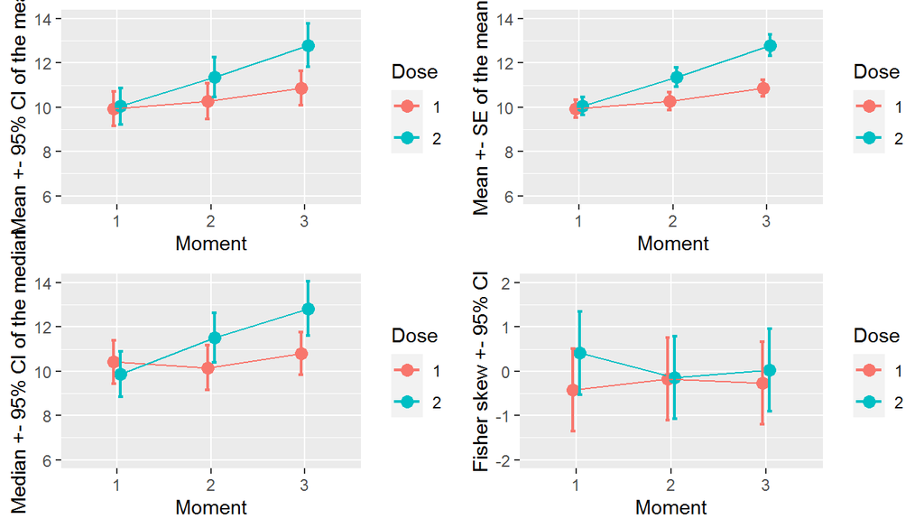

**Figure 1**. Various statistics and various measures of precisions

```r
# shut down 'warnings', 'design' and 'summary' messages
options(superb.feedback = 'none')

# Generate a random dataset from a (3 x 2) design, entirely within subject.
# The sample size is very small (n=5) and the correlation between scores is high (rho = .8)
dta <- GRD(
    WSFactors  = "Moment(3): Dose(2)",
    Effects    = list("Dose*Moment"=custom(0,0,0,1,1,3)),
    SubjectsPerGroup = 50,
    Population = list( mean=10, stddev = 5, rho = .80)
)

# a quick function to call superbPlot
makeplot <- function(statfct, errorbarfct, gam, rg, subttl) {
    superbPlot(dta,
        WSFactors  = c("Moment(3)","Dose(2)"),
        variables = c("DV.1.1","DV.2.1","DV.3.1","DV.1.2","DV.2.2","DV.3.2"),
        statistic = statfct,
        errorbar  = errorbarfct,
        gamma     = gam,
        plotStyle = "line",
        adjustments = list(purpose="difference", decorrelation="CM")
    ) + ylab(subttl) + coord_cartesian( ylim = rg )
}

p1 <- makeplot("mean",      "CI", .95, c(6,14), "Mean +- 95% CI of the mean")
p2 <- makeplot("mean",      "SE", .00, c(6,14), "Mean +- SE of the mean")
p3 <- makeplot("median",    "CI", .95, c(6,14), "Median +- 95% CI of the median")
p4 <- makeplot("fisherskew","CI", .95, c(-2,+2), "Fisher skew +- 95% CI")

library(gridExtra)
p <- grid.arrange(p1,p2,p3,p4, ncol=2)
```

## Determining that a summary function is valid to use in superbPlot

Any summary function can be accepted by `superbPlot`, as long as it is given within double-quote. The built-in statistics functions such as `mean` and `median` can be given. Actually, any descriptive statistics, not just central tendency, can be provided. That includes `IQR`, `mad`, etc. To be valid, the function must return a number when given a vector of numbers.

In doubt, you can test if the function is valid for `superbPlot` with (note the triple colon):

```r
superb:::is.stat.function("mean")
```

```
## [1] TRUE
```

Likewise, any error bar function can be accepted by `superbPlot`. These functions must be named with two part, separated with a dot `"interval function"."descriptive statistic"`. For example, the function `CI.mean` is the confidence interval of the mean. Other functions are `SE.mean`, `SE.median`, `CI.fisherskew`, etc. The `superb` library provides some 20+ such functions. Harding, Tremblay, & Cousineau (2014) and Harding, Tremblay, & Cousineau (2015) reviewed some of these functions.

The error bar functions can be of three types:

- a function that returns a width. Standard error functions are example of this type of function. With width function, the error bar extend plus and minus that width around the descriptive statistics.
- an interval function. Such functions returns the actual lower and upper limits of the interval and therefore are used as is to draw the bar (i.e., they are not relative to the descriptive statistics). Confidence interval functions are of this type.
- `"none"`. This keyword produces an error bar of null width.

The interval function can be tested to see if it exists:

```r
superb:::is.errorbar.function("SE.mean")
```

```
## [1] TRUE
```

To see if a gamma is required for a certain interval function, you can try

```r
superb:::is.gamma.required("SE.mean")
```

```
## [1] FALSE
```

## Creating a custom-made descriptive statistic function to be used in superbPlot

As an example, we create from scratch a descriptive statistic function that will be fed to `superbPlot`. Following Wilcox (2011) , we implement the 20% trimmed mean. This descriptive statistic is used to estimate the population mean. However, it is said to be a robust statistic as it is less affected by suspicious data. Herein, we use the data from `dataFigure1`.

```r
    # create a descriptive statistics, the 20% trimmed mean
    trimmedmean    <- function(x) mean(x, trim = 0.2)

    # we can test it with the data from group 1...
    grp1 <- dataFigure1$score[dataFigure1$grp==1]
    grp2 <- dataFigure1$score[dataFigure1$grp==2]
    trimmedmean(grp1)
```

```
## [1] 106.2667
```

```r
    # or check that it is a valid statistic function
    superb:::is.stat.function("trimmedmean")
```

```
## [1] TRUE
```

Once we have the function, we can ask for a plot of this function with

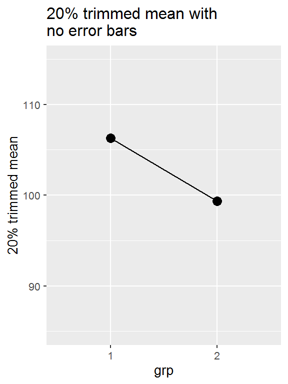

**Figure 2**. `superbPlot` with a custom-made descriptive statistic function

```r
    superbPlot(dataFigure1,
        BSFactors = "grp",
        statistic = "trimmedmean", errorbar = "none", #HERE the statistic name is given
        plotStyle="line",
        adjustments = list(purpose = "difference"),
        variable = "score",
        errorbarParams = list(width=0) # so that the null-width error bar is invisible
    )+ ylab("20% trimmed mean") +
    theme_gray(base_size=10) +
    labs(title="20% trimmed mean with \nno error bars") +
    coord_cartesian( ylim = c(85,115) )
```

## Creating a custom-made interval function to be used in `superbPlot`

It is also possible to create custom-made confidence interval functions.

Hereafter, we add a confidence interval for the 20% trimmed mean. We use the approach documented in Wilcox (Wilcox, 2011) which requires computing the winsorized standard deviation `winsor.sd` as available in the `psych` library (Revelle, 2020).

```r
    library(psych)      # for winsor.sd

    CI.trimmedmean <- function(x, gamma = 0.95){
        trim <- 0.2
        g    <- floor(length(x) * 0.4)
        tc   <- qt(1/2+gamma/2, df=(length(x)-g-1) )
        lo   <- tc * winsor.sd(x, trim =0.2) / ((1-2*trim)*sqrt(length(x)))
        c(trimmedmean(x) -lo, trimmedmean(x)+lo)
    }

    # we test as an example the data from group 1
    CI.trimmedmean(grp1)
```

```
## [1] 101.7281 110.8052
```

```r
    # or check that it is a valid interval function
    superb:::is.errorbar.function("CI.trimmedmean")
```

```
## [1] TRUE
```

We have all we need to make a plot with error bars!

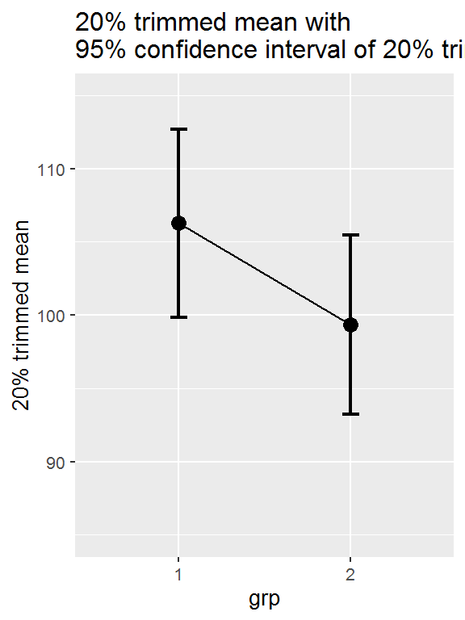

**Figure 3**. `superbPlot` with a custom-made descriptive sttistic function

```r
    superbPlot(dataFigure1,
        BSFactors = "grp",
        statistic = "trimmedmean", errorbar = "CI",
        plotStyle="line",
        adjustments = list(purpose = "difference"),
        variable = "score"
    )+ ylab("20% trimmed mean") +
    theme_gray(base_size=10) +
    labs(title="20% trimmed mean with \n95% confidence interval of 20% trimmed mean") +
    coord_cartesian( ylim = c(85,115) )
```

The advantage of this measure of central tendancy is that it is a robust estimator. Robust measures are less likely to be adversly affected by suspicious data such as outliers. See Wilcox (2011) for more on robust estimation.

## Creating bootstrap-based confidence intervals

It is also possible to create bootstrap estimates of confidence intervals and integrate these into `superb`.

The general idea is to subsample with replacement the sample and compute on this subsample the descriptive statistics. This process is repeated a large number of times (here, 10,000) and the quantiles containing, say, 95% of the results is a 95% precision interval (we call it a *precision interval* as bootstrap estimates the sampling variability, not the predictive variability).

```r
    # we define myBootstrapPI which subsample the whole sample, here called X
    myBootstrapPI.mean <- function(X, gamma = 0.95) {
      res = c()
      for (i in 1:10000) {
        res[i] <- mean(sample(X, length(X), replace = T))
      }
      quantile(res, c(1/2 - gamma/2, 1/2 + gamma/2))
    }

    # we check that it is a valid interval function
    superb:::is.errorbar.function("myBootstrapPI.mean")
```

```
## [1] TRUE
```

This is all we need to make the plot which we can compare with the parametric CI

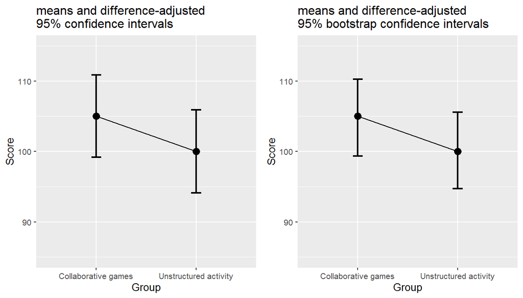

**Figure 4**. `superbPlot` with a custom-made interval function.

```r
    plt1 <- superbPlot(dataFigure1,
        BSFactors = "grp",
        variable = c("score"),
        plotStyle="line",
        statistic = "mean", errorbar = "CI",
        adjustments = list(purpose = "difference")
    ) +
    xlab("Group") + ylab("Score") +
    labs(title="means and difference-adjusted\n95% confidence intervals") +
    coord_cartesian( ylim = c(85,115) ) +
    theme_gray(base_size=10) +
    scale_x_discrete(labels=c("1" = "Collaborative games", "2" = "Unstructured activity"))

    plt2 <- superbPlot(dataFigure1,
        BSFactors = "grp",
        variable = c("score"),
        plotStyle="line",
        statistic = "mean", errorbar = "myBootstrapPI",
        adjustments = list(purpose = "difference")
    ) +
    xlab("Group") + ylab("Score") +
    labs(title="means and difference-adjusted\n95% bootstrap confidence intervals") +
    coord_cartesian( ylim = c(85,115) ) +
    theme_gray(base_size=10) +
    scale_x_discrete(labels=c("1" = "Collaborative games", "2" = "Unstructured activity"))

    library(gridExtra)
    plt <- grid.arrange(plt1, plt2, ncol=2)
```

As seen, there is not much difference between the two. This was expected: when the normality assumption is not invalid, the *parametric* confidence intervals of the mean (based on this assumption) is identical on average to the bootstrap approach.

## In summary

The function `superbPlot()` is entirely customizable: you can put any descriptive statistic function and any interval function into `superbPlot()`. In a sense, `superbPlot()` is simply a proxy that manage the dataset and produces standardized dataframes apt to be transmitted to a `ggplot()` specification. It is also possible to obtain the summary dataframe by issuing the argument `showPlot = FALSE` or by using the related function `superbData()`.

The function `superbPlot` is also customizable with regards to the plot produced. Included in the package are

- `superbPlot.line` : shows the results as points and lines,
- `superbPlot.point`: shows the results as points only,
- `superbPlot.bar` : shows the results using bars,
- `superbPlot.pointjitter`: shows the results with points, and the raw data with jittered points,
- `superbPlot.pointjitterviolin`: also shows violin plot behind the jitter points, and
- `superbPlot.pointindividualline`: show the results with fat points, and individual results with thin lines,
- `superbPlot.raincloud`: show the results along with clouds (violin distributions) and rain drops (jittered raw data),

[Vignette 5](https://dcousin3.github.io/superb/articles/Vignette5.html) shows how to create new layouts. Proposals are welcome!

# References

Harding, B., Tremblay, C., & Cousineau, D. (2014). Standard errors: A review and evaluation of standard error estimators using monte carlo simulations. *The Quantitative Methods for Psychology*, *10*(2), 107–123.

Harding, B., Tremblay, C., & Cousineau, D. (2015). The standard error of the pearson skew. *The Quantitative Methods for Psychology*, *11*(1), 32–36.

Revelle, W. (2020). *Psych: Procedures for psychological, psychometric, and personality research*. Evanston, Illinois: Northwestern University. Retrieved from https://CRAN.R-project.org/package=psych

Wilcox, R. R. (2011). *Introduction to robust estimation and hypothesis testing*. Academic press.